# MB5370 Module 04. Data Science in R 1

## Troubleshooting

### Aesthetic Mappings

You can add a third variable to plots, such as class

#### Change point color by class:

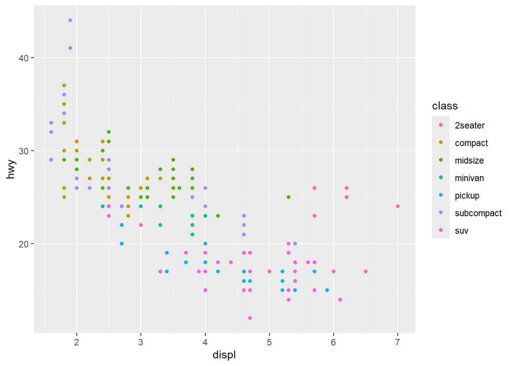

```r
ggplot(data = mpg) +
  geom_point(mapping = aes(x = displ, y = hwy, color = class))
```

#### Change point size by class:

```
## Warning: Using size for a discrete variable is not advised.
```

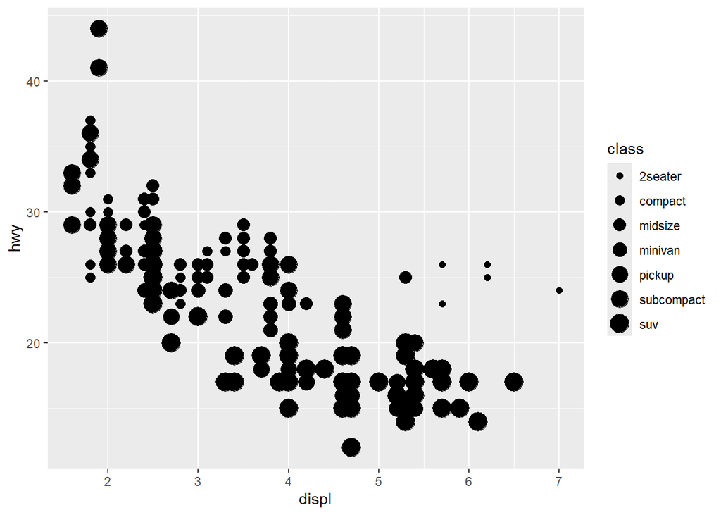

```r
ggplot(data = mpg) +
  geom_point(mapping = aes(x = displ, y = hwy, size = class))
```

Note the warning!!!“Using size for a discrete variable is not advised”.

#### Change transparency (alpha) by class

```
## Warning: Using alpha for a discrete variable is not advised.
```

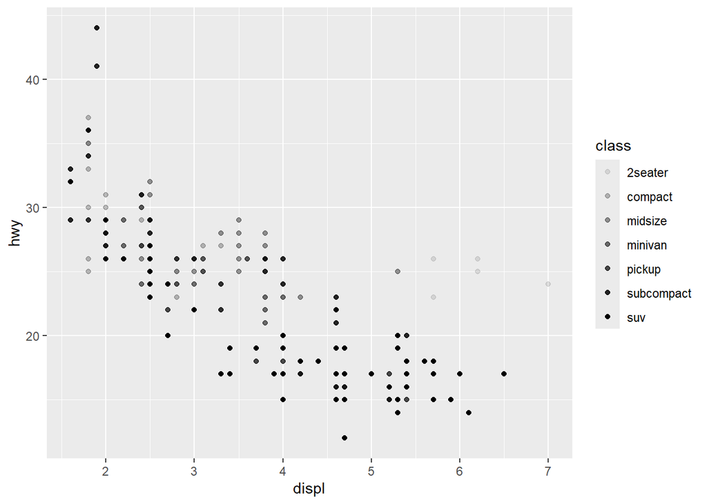

```r
ggplot(data = mpg) +
  geom_point(mapping = aes(x = displ, y = hwy, alpha = class))
```

Another warning!! “Using alpha for a discrete variable is not advised”.

#### Change point shape by class:

```
## Warning: The shape palette can deal with a maximum of 6 discrete values because more
## than 6 becomes difficult to discriminate
## ℹ you have requested 7 values. Consider specifying shapes manually if you need
##   that many have them.
```

```
## Warning: Removed 62 rows containing missing values or values outside the scale range
## (`geom_point()`).
```

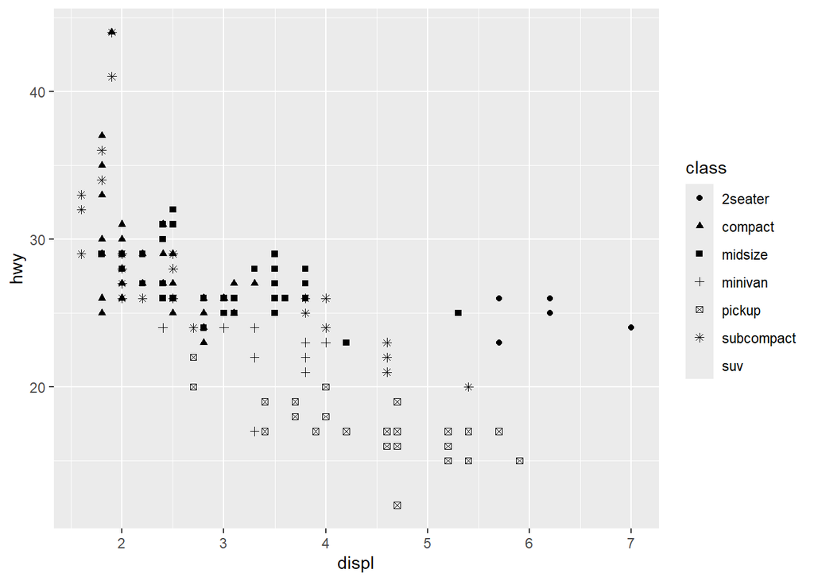

```r
ggplot(data = mpg) +
  geom_point(mapping = aes(x = displ, y = hwy, shape = class))
```

You must specify shapes manually because the shape function can only handle a max of 6 values

#### Make all points purple

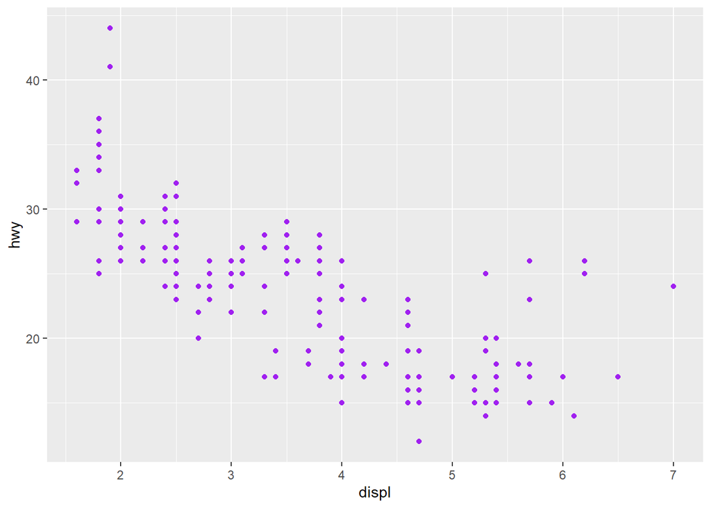

```r
ggplot(data = mpg) +
  geom_point(mapping = aes(x = displ, y = hwy), color = "purple")
```

#### Change point color based on TRUE or FALSE

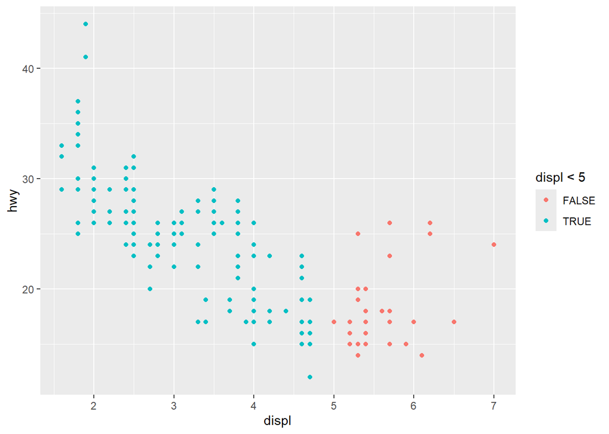

```r
ggplot(data = mpg) + geom_point(mapping = aes(x = displ, y = hwy, color = displ < 5))
```

Makes it a logical function (True or False) and changes color to reflect that